# Research demo

Richel Bilderbeek

2016-05-24

This document describes my research. It does so by showing the workflow for toy examples.

## Workflow

Every experiment has the following steps:

- Starting up
- Creating parameter files
- Simulate one incipient species tree per parameter file
- Once or more often, sample unique species from an incipient species tree
- Per sampled species tree, add an outgroup
- Simulate one or more alignments per species tree
- Once or more often, let BEAST2 infer a posterior per alignment
- Compare original, sampled species tree, to the posterior

## Creating parameter files

We will need to load some libraries:

```r
library(Cer2016)
library(ape)
```

We create four parameter files:

```r
filenames <- c(
  "toy_example_1.RDa",
  "toy_example_2.RDa",
  "toy_example_3.RDa",
  "toy_example_4.RDa"
)
```

To be sure to have a fresh analysis, we delete the files if they exist:

```r
#for (filename in filenames) {
#  if (file.exists(filename)) {
#    file.remove(filename)
#  }
#}
```

Now the parameter files are created with some parameters:

```r
rng_seeds <- seq(1,4)
sirgs <- rep(0.5, times = 4)
siris <- rep(0.5, times = 4)
scrs <- rep(1.0, times = 4)
ergs <- rep(0.1, times = 4)
eris <- rep(0.1, times = 4)
ages <- rep(5, times = 4)
n_species_trees_sampleses <- c(1, 1, 2, 2)
mutation_rates <- rep(0.01, times = 4)
n_alignmentses <- c(1, 1, 2, 2)
sequence_lengths <- rep(1000, times = 4)
mcmc_chainlengths <- rep(10000, times = 4)
n_beast_runses <- c(1, 1, 2, 2)
for (i in seq(1, 4)) {
  save_parameters_to_file(
    rng_seed = rng_seeds[i],
    sirg = sirgs[i],
    siri = siris[i],
    scr = scrs[i],
    erg = ergs[i],
    eri = eris[i],
    age = ages[i],
    n_species_trees_samples = n_species_trees_sampleses[i],
    add_outgroup = TRUE,
    mutation_rate = mutation_rates[i],
    n_alignments = n_alignmentses[i],
    sequence_length = sequence_lengths[i],
    mcmc_chainlength = mcmc_chainlengths[i],
    n_beast_runs = n_beast_runses[i],
    filename = filenames[i]
  )
}
```

Note that they all have a different random number generator seed. Because they do have different other parameters, this is no problem. [TODO: Test this]

### Simulate one incipient species tree per parameter file

Here we simulate the ‘true’ incipient species tree:

```r
for (filename in filenames) {
  add_pbd_output(filename)
}
```

This is how these look like, both the incipient species phylogenies and an nLTT plots:

```
## [1] "toy_example_1.RDa"
```

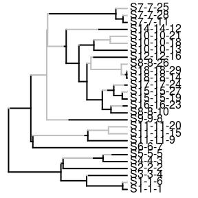

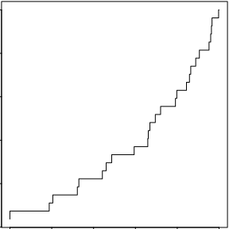

```
## [1] "toy_example_2.RDa"
```

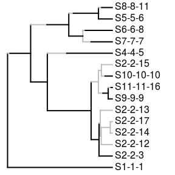

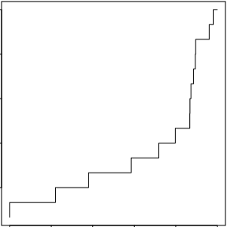

```
## [1] "toy_example_3.RDa"
```

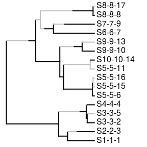

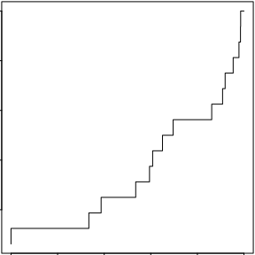

```
## [1] "toy_example_4.RDa"
```

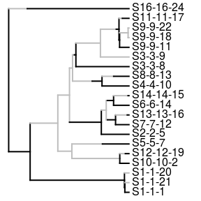

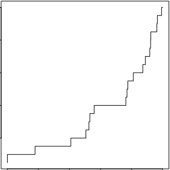

```r
colors <- setNames(c("gray","black"), c("i","g"))

for (filename in filenames) {
  testit::assert(is_valid_file(filename))
  testit::assert(length(read_file(filename)$pbd_output$igtree.extant$tip.label) > 0)
  print(filename)
  phytools::plotSimmap(
    read_file(filename)$pbd_output$igtree.extant,
    colors = colors
  )
  nLTT::nLTT.plot(read_file(filename)$pbd_output$tree)
}
```

## Once or more often, sample unique species from an incipient species tree. Then, per sampled species tree, add an outgroup

Here we simulate the ‘true’ incipient species tree:

```r
for (filename in filenames) {
  add_species_trees_with_outgroup(filename)
}
```

```
## [1] "Adding species_trees_with_outgroup to file toy_example_1.RDa"
## [1] "   * Setting seed to 2"
## [1] "Added species_trees_with_outgroup to file toy_example_1.RDa"
## [1] "Adding species_trees_with_outgroup to file toy_example_2.RDa"
## [1] "   * Setting seed to 3"
## [1] "Added species_trees_with_outgroup to file toy_example_2.RDa"
## [1] "Adding species_trees_with_outgroup to file toy_example_3.RDa"
## [1] "   * Setting seed to 4"
## [1] "   * Setting seed to 5"
## [1] "Added species_trees_with_outgroup to file toy_example_3.RDa"
## [1] "Adding species_trees_with_outgroup to file toy_example_4.RDa"
## [1] "   * Setting seed to 5"
## [1] "   * Setting seed to 6"
## [1] "Added species_trees_with_outgroup to file toy_example_4.RDa"
```

Those are shown here. Note that run 1 and 2 have no replicate and thus produce only one sampled tree.

```
## [1] "toy_example_1.RDa"
```

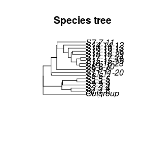

```
## [1] "toy_example_2.RDa"
```

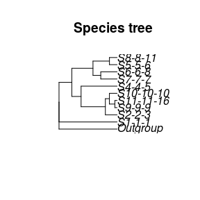

```
## [1] "toy_example_3.RDa"
```

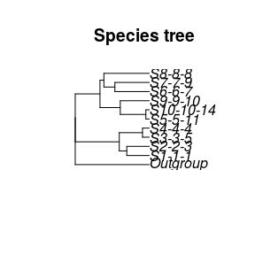

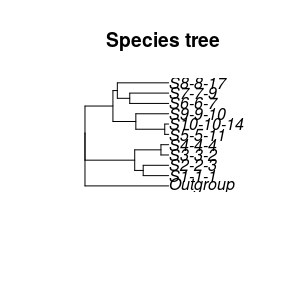

```
## [1] "toy_example_4.RDa"
```

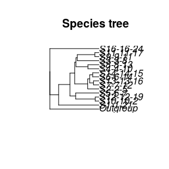

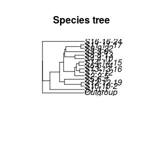

```r
for (filename in filenames) {
  print(filename)
  plot_species_tree_with_outgroup(filename)
}
```

## Add alignments

```r
for (filename in filenames) {
  add_alignments(filename)
}
```

```
## [1] "   * Created and saved alignments[1]"
## [1] "file toy_example_1.RDa has gotten its 1 alignments (per species tree)"
## [1] "   * Created and saved alignments[1]"
## [1] "file toy_example_2.RDa has gotten its 1 alignments (per species tree)"
## [1] "   * Created and saved alignments[1]"
## [1] "   * Created and saved alignments[2]"
## [1] "   * Created and saved alignments[3]"
## [1] "   * Created and saved alignments[4]"
## [1] "file toy_example_3.RDa has gotten its 2 alignments (per species tree)"
## [1] "   * Created and saved alignments[1]"
## [1] "   * Created and saved alignments[2]"
## [1] "   * Created and saved alignments[3]"
## [1] "   * Created and saved alignments[4]"
## [1] "file toy_example_4.RDa has gotten its 2 alignments (per species tree)"
```

```
## [1] "toy_example_1.RDa"
```

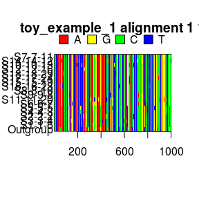

```
## [1] "toy_example_2.RDa"
```

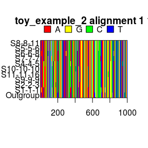

```
## [1] "toy_example_3.RDa"
```

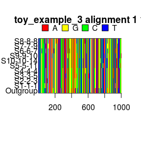

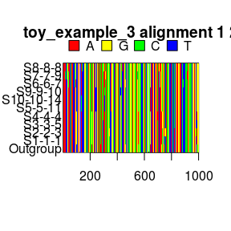

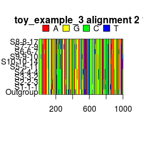

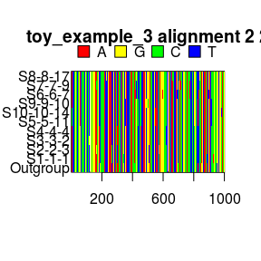

```
## [1] "toy_example_4.RDa"
```

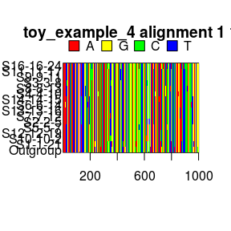

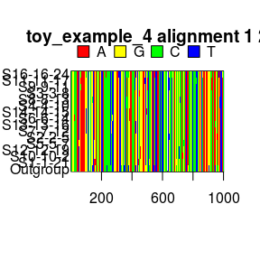

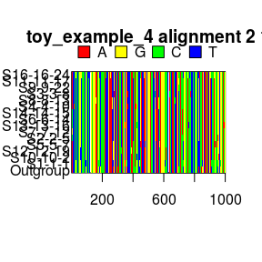

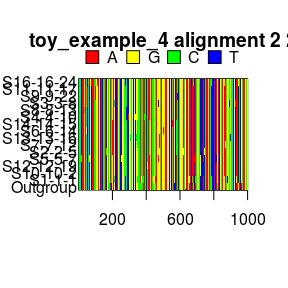

```r
for (filename in filenames) {
  print(filename)
  plot_alignments(filename)
}
```

## Add posteriors

```r
for (filename in filenames) {
  add_posteriors(
    filename,
    skip_if_output_present = TRUE
  )
}
```

```
## [1] "   * Setting seed to 2"
## [1] "   * Storing posterior #1 for alignment #1 for species tree #1 at posterior_index #1"
## [1] "file toy_example_1.RDa has gotten its posteriors"
## [1] "   * Setting seed to 3"
## [1] "   * Storing posterior #1 for alignment #1 for species tree #1 at posterior_index #1"
## [1] "file toy_example_2.RDa has gotten its posteriors"
## [1] "   * Setting seed to 4"
## [1] "   * Storing posterior #1 for alignment #1 for species tree #1 at posterior_index #1"
## [1] "   * Setting seed to 5"
## [1] "   * Storing posterior #2 for alignment #1 for species tree #1 at posterior_index #2"
## [1] "   * Setting seed to 4"
## [1] "   * Storing posterior #1 for alignment #2 for species tree #1 at posterior_index #3"
## [1] "   * Setting seed to 5"
## [1] "   * Storing posterior #2 for alignment #2 for species tree #1 at posterior_index #4"
## [1] "   * Setting seed to 4"
```

[output cut: 25 more lines]

```
## [1] "toy_example_1.RDa"
```

[output not shown]

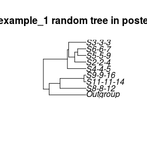

[output not shown]

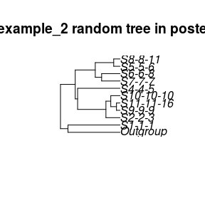

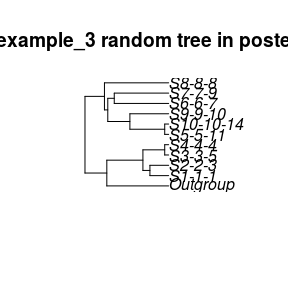

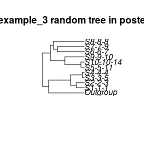

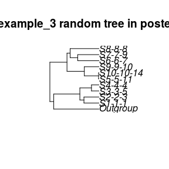

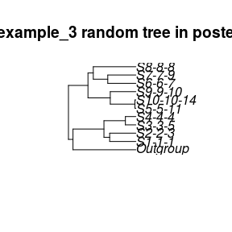

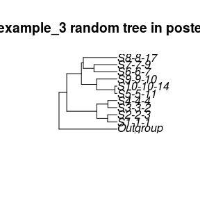

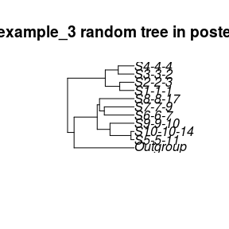

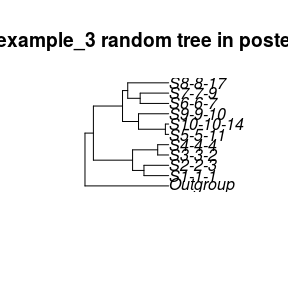

[output not shown]

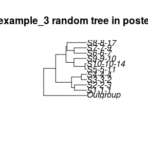

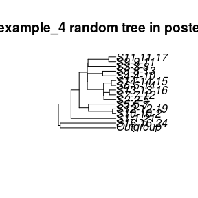

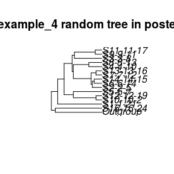

[6 more figures not shown]

```r
for (filename in filenames) {
  print(filename)
  plot_posterior_samples(filename)
  plot_posterior_sample_nltts(filename)
}
```

Let’s view the (single) posteriors of the first two files:

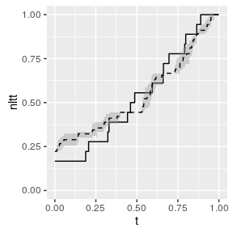

```r
plot_posterior_nltts(filenames[1])
```

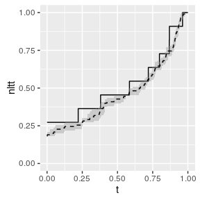

```r
plot_posterior_nltts(filenames[2])
```

The third and fourth parameter files have had two BEAST2 runs. We can see how similar these are:

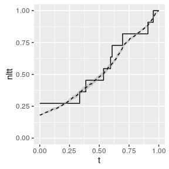

```r
plot_posterior_nltts(filenames[3])
```

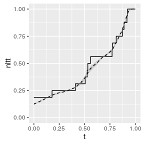

```r
plot_posterior_nltts(filenames[4])
```